# Graphics with with ggplot2

# What is ggplot

- ggplot2 is an R package for producing statistical, or data, graphics.
- Under the tidyverse family of packages
- ggplot2 has an underlying grammar, based on the Grammar of Graphics
- compose graphs by combining independent components.

# How ggplot works

- ggplot2 divides plot into three different fundamental parts:
  - Plot = data + Aesthetics + Geometry
- The principal components of every plot can be defined as follow:
  - **data** is a data frame
  - **Aesthetics** is used to indicate x and y variables. It can also be used to control the color, the size or the shape of points, the height of bars, etc…..
  - **Geometry** defines the type of graphics (histogram, box plot, line plot, density plot, dot plot, ….)

# Install ggplot2

```r
# Installation
install.packages("ggplot2")
# Loading
library(ggplot2)
```

# Load the data

```r
setwd("where/your/work/folder/is/")
```

```r
library(readr)
bw_df <- read_csv("day1_birth_weight.csv")
```

# Why?

- To have an understanding of you data we normally conduct exploratory data analysis (EDA) which can be graphical or numerical
- Primarily EDA is for seeing what the data can tell us before the formal modelling or hypothesis testing task
- Typical graphical techniques used in EDA are:
  - Scatter plots,
  - Box plots,
  - Bar plots

# Scatter with base R

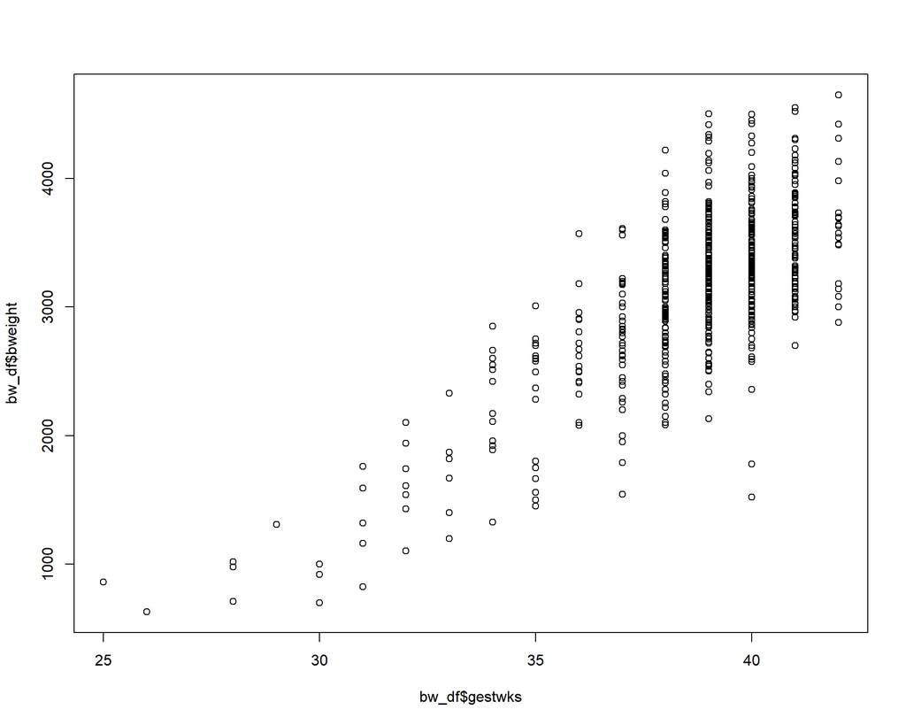

```r
plot(bw_df$gestwks, bw_df$bweight)
```

# Elements of grammar of graphics

- Data: variables mapped to aesthetic (aes function) features of the graph.
- Geoms: objects/shapes on the graph.
- Stats: stastical transformations that summarize data,(e.g mean, confidence intervals)
- Scales: define which aesthetic values are mapped to data values. Legends and axes display these mappings.
- Coordiante systems: define the plane on which data are mapped on the graphic.
- Faceting: splits the data into subsets to create multiple variations of the same graph (paneling).

# Aesthetic mappings and aes

- Aesthetics are the visually perceivable components of the graph.
- Map variables to aesthetics using the aes function, such as:
  - which variables appear on the x-axis and y-axis.
  - a classification variable to colors
  - a numeric variable to the size of graphical objects

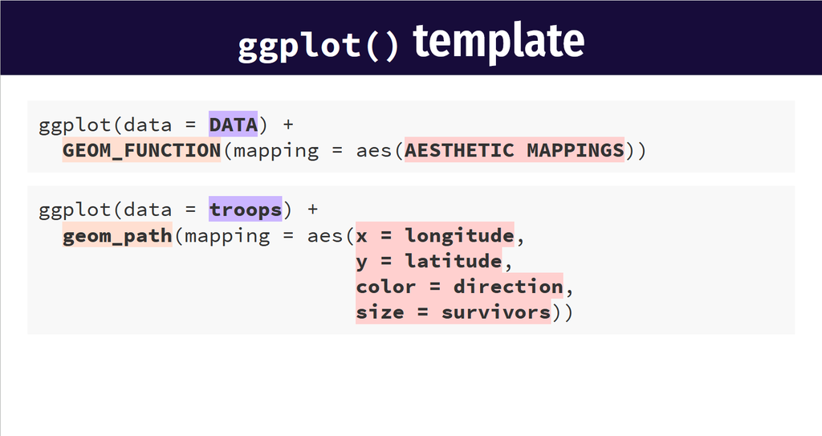

# Scatter plot with ggplot2

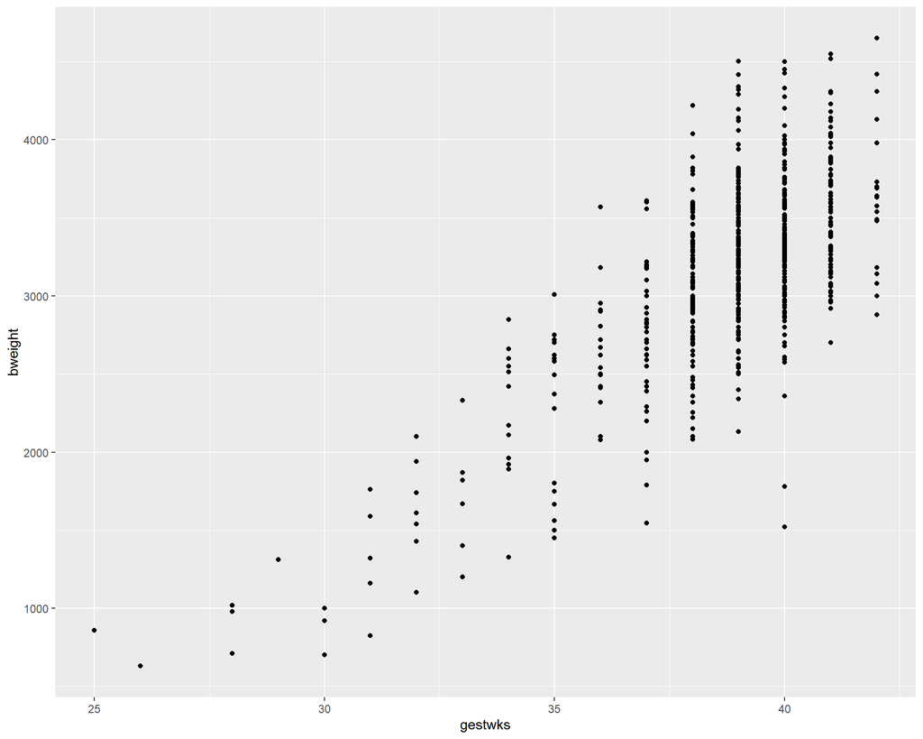

[figure not shown]

```r
# declare data and x and y aesthetics, but no shapes yet
ggplot(data = bw_df) + geom_point(mapping = aes(x = gestwks,
    y = bweight))
```

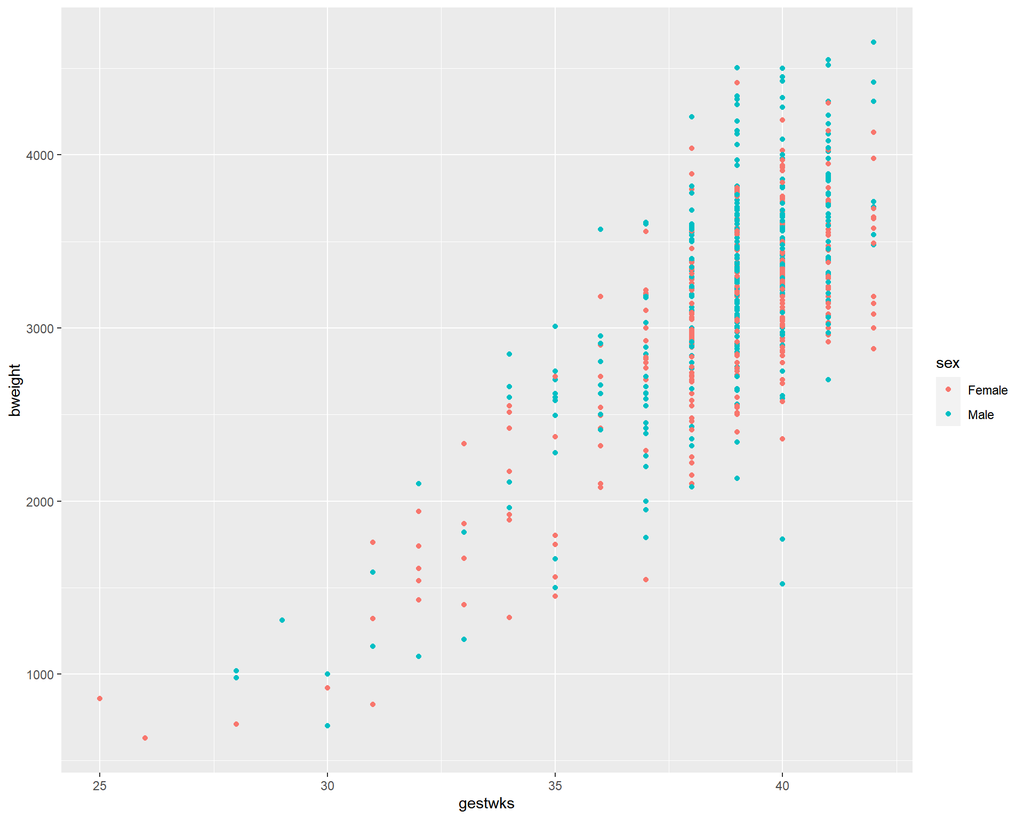

```r
ggplot(data = bw_df) + geom_point(mapping = aes(x = gestwks,
    y = bweight, color = sex))
```

# Boxplot

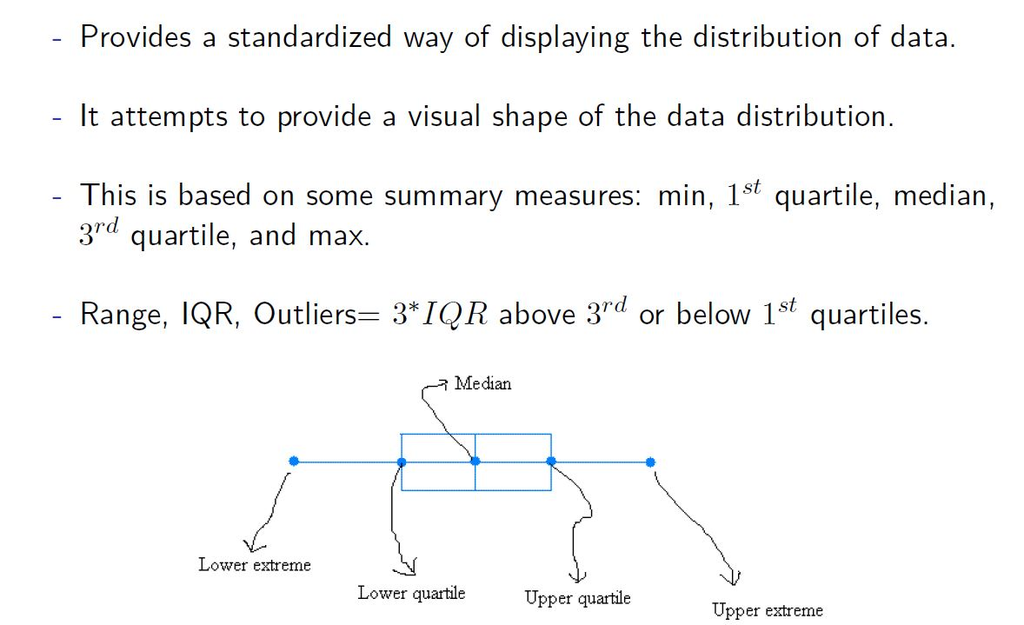

# Definition

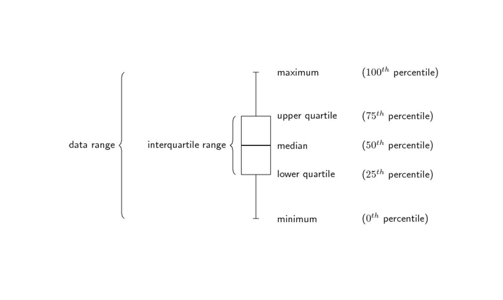

# Lets do a Box plot?

- A box plot of bweight vs sex

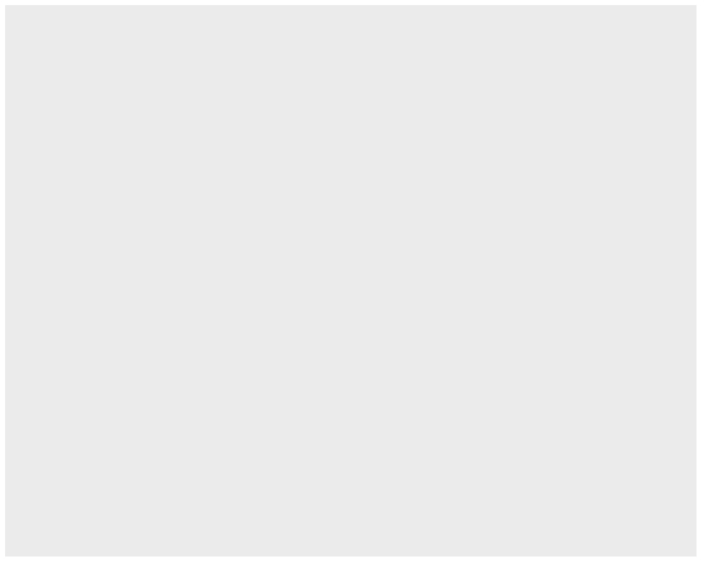

```r
ggplot(data = bw_df)
```

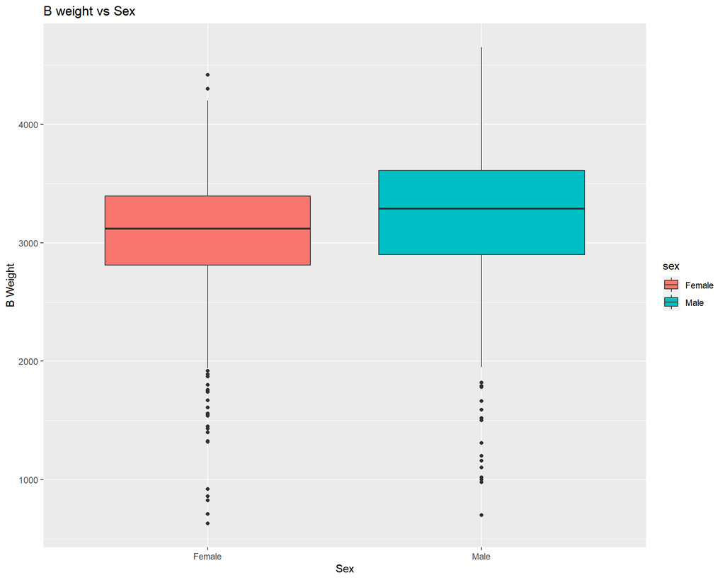

```r
ggplot(data = bw_df) + geom_boxplot(aes(y = bweight, x = sex,
    fill = sex)) + ylab("B Weight") + xlab("Sex") + ggtitle("B weight vs Sex")
```

# Box plot and add scatter

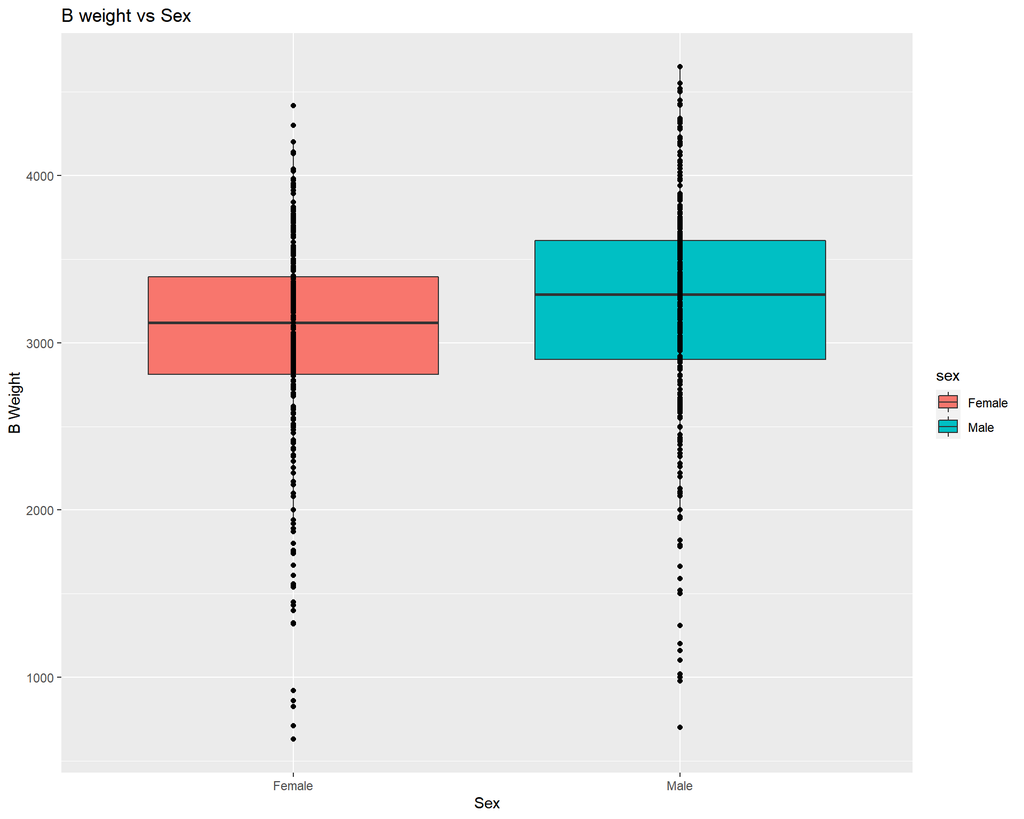

```r
ggplot(data = bw_df) + geom_boxplot(aes(y = bweight, x = sex,
    fill = sex)) + # geom_jitter(aes(y=bweight, x=sex))+
geom_point(aes(y = bweight, x = sex)) + ylab("B Weight") + xlab("Sex") +
    ggtitle("B weight vs Sex")
```

# Putting it all together

We can build a plot sequentially  
to see how each grammatical layer  
changes the appearance

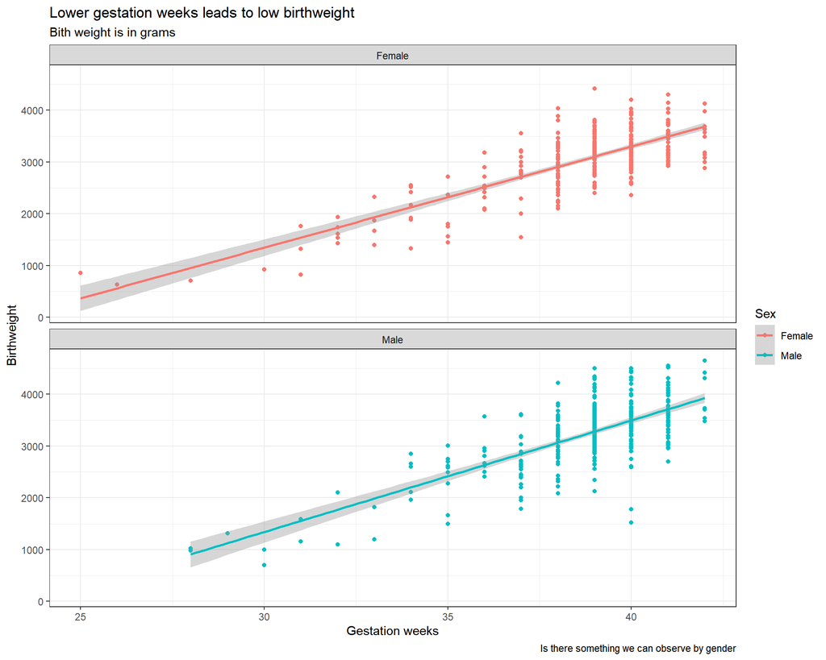

# Start with data and aesthetics

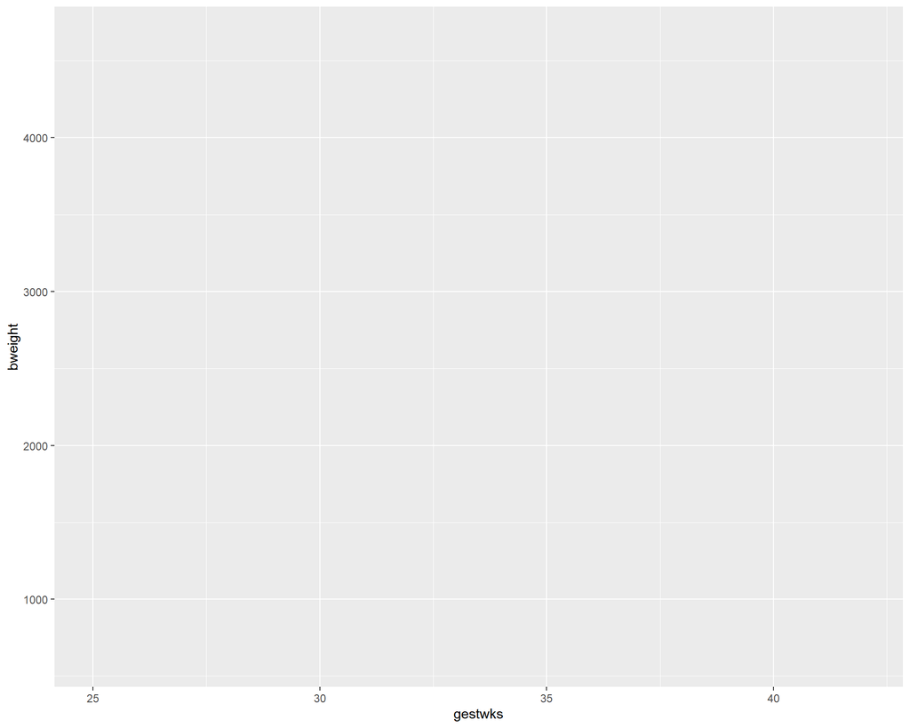

```r
# Start with data and aesthetics
ggplot(data = bw_df, mapping = aes(x = gestwks, y = bweight,
    color = sex))
```

# Add a point geom

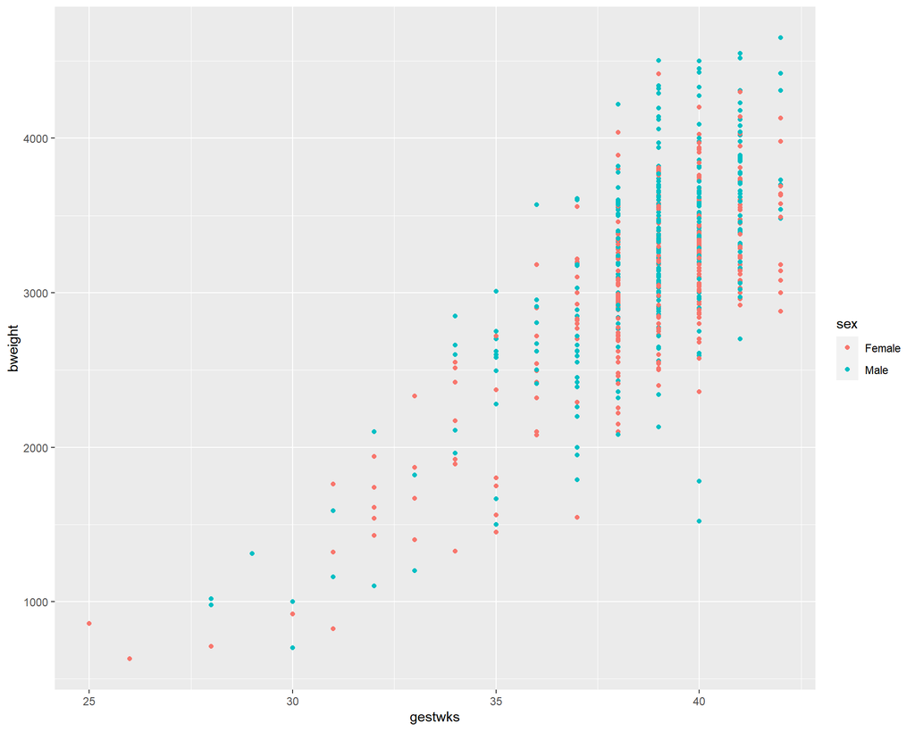

```r
# Start with data and aesthetics
ggplot(data = bw_df, mapping = aes(x = gestwks, y = bweight,
    color = sex)) + # Add a point geom
geom_point()
```

# Add a smooth geom

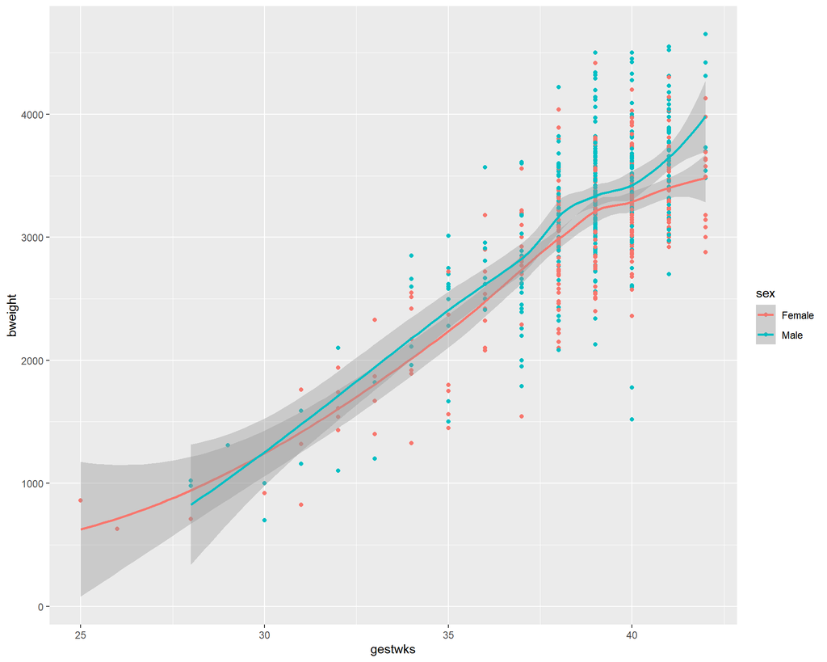

```r
# Start with data and aesthetics
ggplot(data = bw_df, mapping = aes(x = gestwks, y = bweight,
    color = sex)) + # Add a point geom
geom_point() + ## Add a smooth geom
geom_smooth()
```

# Make the smooth geom straight

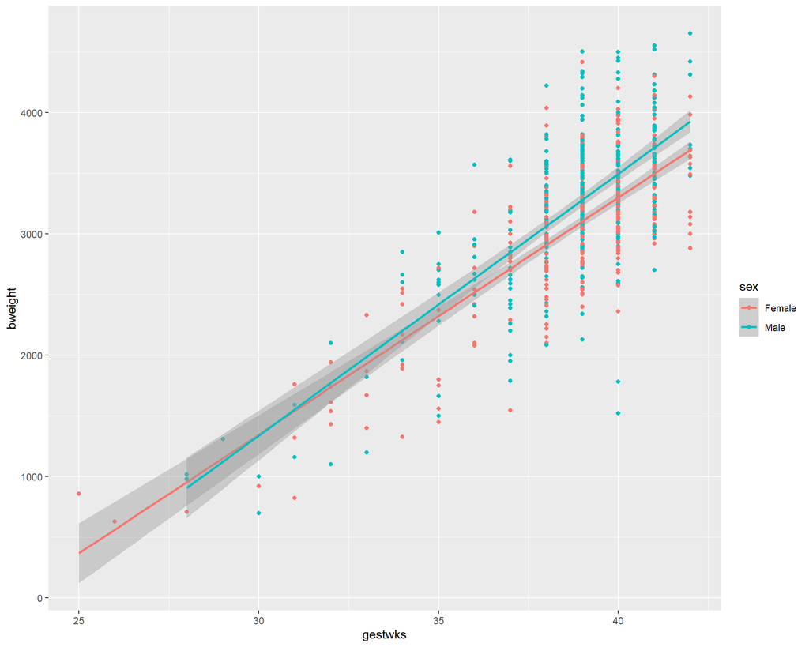

```r
# Start with data and aesthetics
ggplot(data = bw_df, mapping = aes(x = gestwks, y = bweight,
    color = sex)) + # Add a point geom
geom_point() + ## Add a smooth geom geom_smooth() + Make it straight
geom_smooth(method = "lm")
```

# Facet by sex

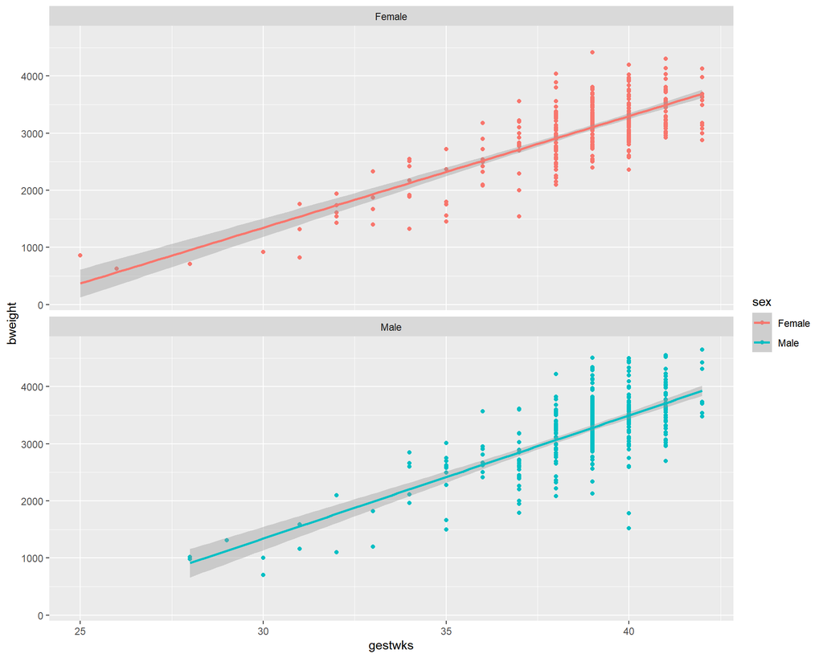

```r
# Start with data and aesthetics
ggplot(data = bw_df, mapping = aes(x = gestwks, y = bweight,
    color = sex)) + # Add a point geom
geom_point() + ## Add a smooth geom geom_smooth() + Make it straight
geom_smooth(method = "lm") + # Facet by sex
facet_wrap(vars(sex), ncol = 1)
```

# add labels

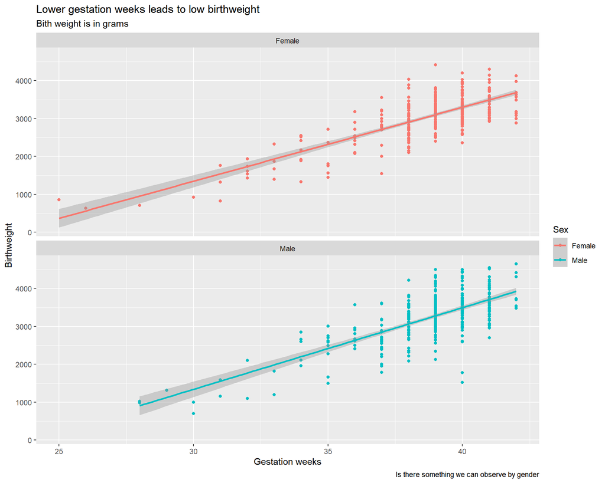

```r
# Start with data and aesthetics
ggplot(data = bw_df, mapping = aes(x = gestwks, y = bweight,
    color = sex)) + # Add a point geom
geom_point() + ## Add a smooth geom geom_smooth() + Make it straight
geom_smooth(method = "lm") + # Facet by sex
facet_wrap(vars(sex), ncol = 1) + ## add labels
labs(x = "Gestation weeks", y = "Birthweight", color = "Sex",
    title = "Lower gestation weeks leads to low birthweight",
    subtitle = "Bith weight is in grams", caption = "Is there something we can observe by gender")
```

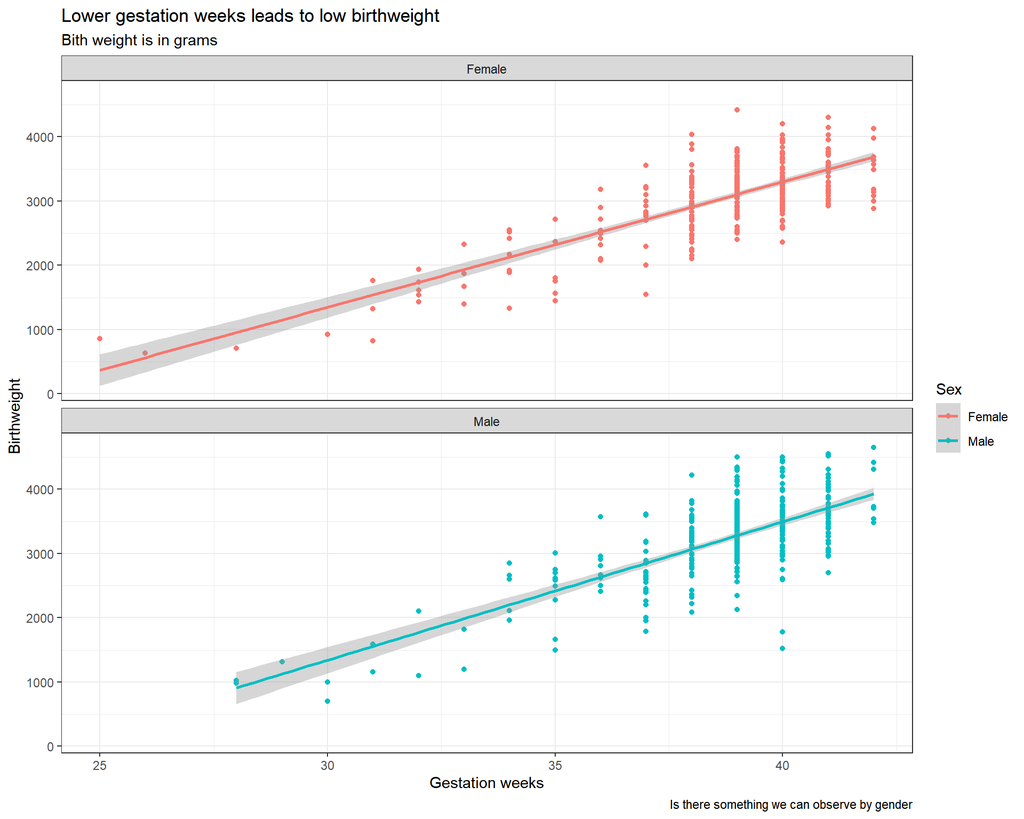

```r
# Start with data and aesthetics
ggplot(data = bw_df, mapping = aes(x = gestwks, y = bweight,
    color = sex)) + # Add a point geom
geom_point() + ## Add a smooth geom geom_smooth() + Make it straight
geom_smooth(method = "lm") + # Facet by sex
facet_wrap(vars(sex), ncol = 1) + ## add labels
labs(x = "Gestation weeks", y = "Birthweight", color = "Sex",
    title = "Lower gestation weeks leads to low birthweight",
    subtitle = "Bith weight is in grams", caption = "Is there something we can observe by gender") +
    # Add a theme
theme_bw()
```

# Themes

https://ggplot2.tidyverse.org/reference/ggtheme.html

# Other types of graphs

http://www.sthda.com/english/wiki/be-awesome-in-ggplot2-a-practical-guide-to-be-highly-effective-r-software-and-data-visualization